# Bank Marketing Data Notebook

## Modeling

With our data fully preprocessed and engineered, we now proceed to the modeling phase. In this section, we'll train and evaluate a variety of classification algorithms to find the best performer for our business problem. Each model will be evaluated using a stratified cross-validation strategy to ensure fair and robust comparison.

```python
# Removing `y` from categorical_features list
categorical_features.remove('y')

# Separating features and target variable
X_engineered = df_engineered.drop('y', axis=1)
y_engineered = df_engineered['y'].map({'yes': 1, 'no': 0}) # Encoding target variable as binary

print("--- Features and Target Variable ---")
print("\nFeatures:\n")
print(X_engineered.shape)
print('\n')
print(X_engineered.head())
print("\nTarget Variable:\n")
print(y_engineered.shape)
print('\n')
print(y_engineered.head())
print("\n------------------------------------\n")
print("Missing Data Check:\n")
print(df_engineered.isnull().sum())
print("\n------------------------------------\n")
```

```
--- Features and Target Variable ---

Features:

(45211, 15)


   age           job  marital  education default  balance housing loan  \
0   58    management  married   tertiary      no     2143     yes   no
1   44    technician   single  secondary      no       29     yes   no
2   33  entrepreneur  married  secondary      no        2     yes  yes
3   47   blue-collar  married    unknown      no     1506     yes   no
4   33       unknown   single    unknown      no        1      no   no

   contact day_of_month month  campaign poutcome was_previously_contacted  \
0  unknown            5   may         1  unknown                       no
1  unknown            5   may         1  unknown                       no
2  unknown            5   may         1  unknown                       no
3  unknown            5   may         1  unknown                       no
4  unknown            5   may         1  unknown                       no

  had_previous_contact
0                   no
1                   no
2                   no
3                   no
4                   no

Target Variable:

(45211,)


0    0
1    0
2    0
3    0
4    0
Name: y, dtype: int64

```

[output cut: 8 more lines]

```
default                     0
balance                     0
housing                     0
loan                        0
contact                     0
day_of_month                0
month                       0
campaign                    0
poutcome                    0
y                           0
was_previously_contacted    0
had_previous_contact        0
dtype: int64

------------------------------------
```

```python
# Splitting the dataset into training and testing sets
X_train, X_test, y_train, y_test = train_test_split(
    X_engineered, y_engineered, test_size=0.2, random_state=seed, stratify=y_engineered)

print("--- Train-Test Split ---\n")
print(f"Training set shape: {X_train.shape}, {y_train.shape}")
print(f"Testing set shape: {X_test.shape}, {y_test.shape}")
```

```
--- Train-Test Split ---

Training set shape: (36168, 15), (36168,)
Testing set shape: (9043, 15), (9043,)
```

```
Categorical Features (Engineered):
 Index(['job', 'marital', 'education', 'default', 'housing', 'loan', 'contact',
       'day_of_month', 'month', 'poutcome', 'was_previously_contacted',
       'had_previous_contact'],
      dtype='object')

Numerical Features (Engineered):
 Index(['age', 'balance', 'campaign'], dtype='object')

------------------------------------


Preprocessor (Engineered):
 ColumnTransformer(transformers=[('cat', OneHotEncoder(handle_unknown='ignore'),
                                 Index(['job', 'marital', 'education', 'default', 'housing', 'loan', 'contact',
       'day_of_month', 'month', 'poutcome', 'was_previously_contacted',
       'had_previous_contact'],
      dtype='object')),
                                ('num', PowerTransformer(),
                                 Index(['age', 'balance', 'campaign'], dtype='object'))])

------------------------------------


--- Model Evaluation with Cross-Validation ---
```

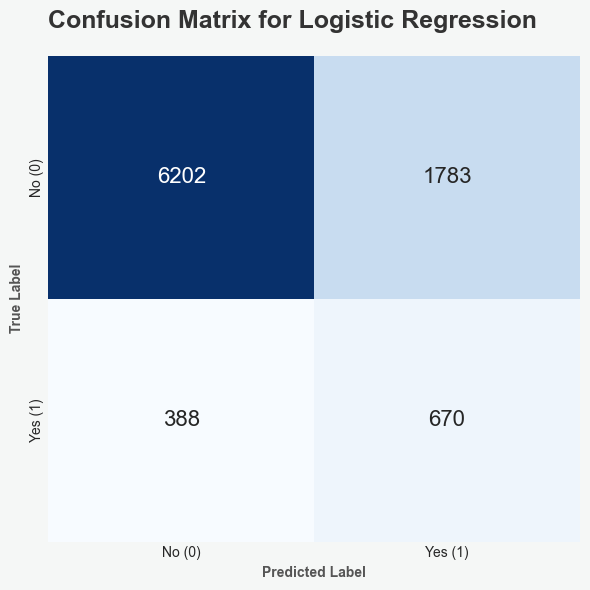

```
Logistic Regression evaluated in 3.03 seconds.
```

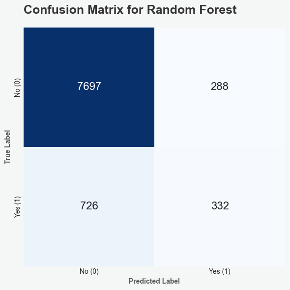

```
Random Forest evaluated in 106.48 seconds.
```

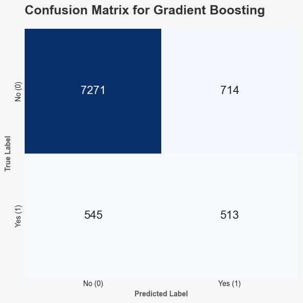

```
Gradient Boosting evaluated in 38.54 seconds.
```

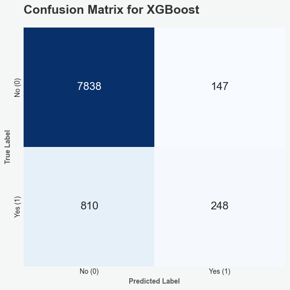

```
XGBoost evaluated in 4.76 seconds.
```

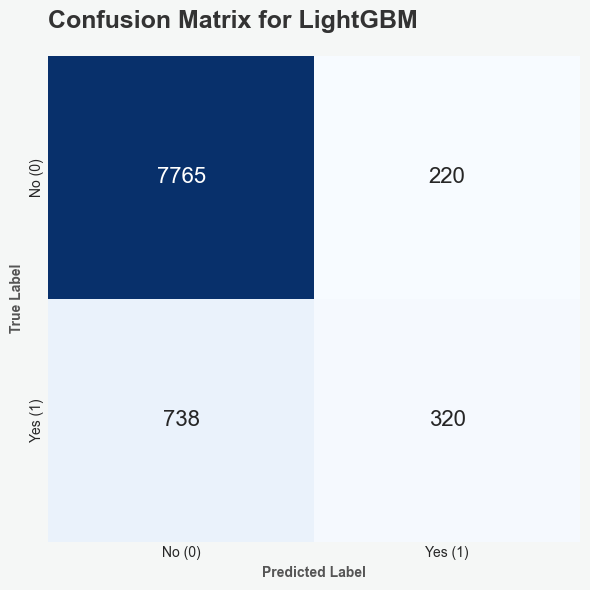

```
LightGBM evaluated in 5.49 seconds.

Cross-Validation Results:
```

|  | Model | Precision | Recall | F1-Score | ROC AUC | Training Time (s) |
| --- | --- | --- | --- | --- | --- | --- |
| 0 | Logistic Regression | 0.27 | 0.63 | 0.38 | 0.76 | 3.03 |
| 1 | Random Forest | 0.52 | 0.30 | 0.38 | 0.78 | 106.48 |
| 2 | Gradient Boosting | 0.42 | 0.45 | 0.43 | 0.77 | 38.54 |
| 3 | XGBoost | 0.60 | 0.22 | 0.33 | 0.78 | 4.76 |
| 4 | LightGBM | 0.56 | 0.29 | 0.38 | 0.79 | 5.49 |

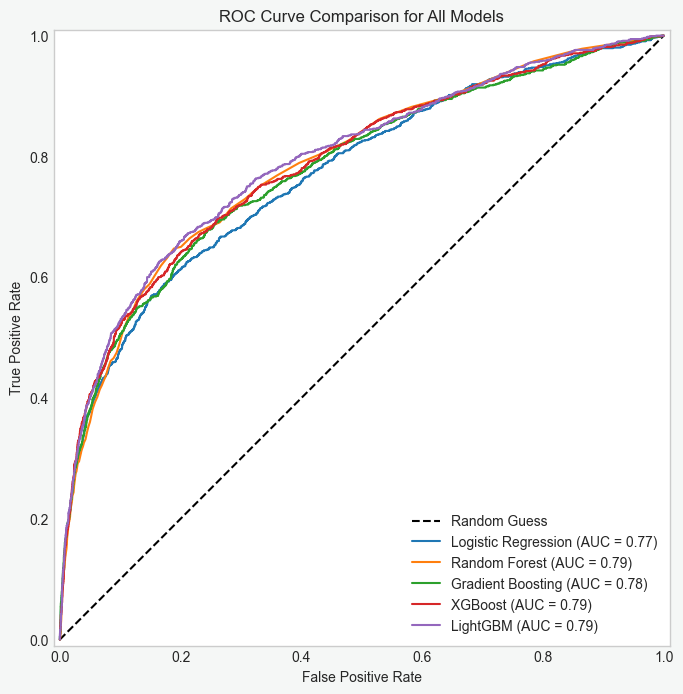

```python
# --- Model Building and Evaluation ---
# Identifying categorical and numerical features for preprocessing
categorical_features_engineered = X_train.select_dtypes(include=['object']).columns
numerical_features_engineered = X_train.select_dtypes(include=np.number).columns
print("\nCategorical Features (Engineered):\n", categorical_features_engineered)
print("\nNumerical Features (Engineered):\n", numerical_features_engineered)
print("\n------------------------------------\n")

# Creating preprocessor for encoding categorical features and scaling numerical features
preprocessor_engineered = ColumnTransformer(
    transformers=[
        ('cat', OneHotEncoder(handle_unknown='ignore'), categorical_features_engineered),
        ('num', PowerTransformer(method='yeo-johnson'), numerical_features_engineered)
    ])
print("\nPreprocessor (Engineered):\n", preprocessor_engineered)
print("\n------------------------------------\n")

# Defining models to compare
models = {
    "Logistic Regression": LogisticRegression(class_weight='balanced', random_state=seed, max_iter=1000),
    "Random Forest": RandomForestClassifier(class_weight='balanced', random_state=seed),
    "Gradient Boosting": GradientBoostingClassifier(random_state=seed),
    "XGBoost": XGBClassifier(eval_metric='logloss', random_state=seed),
    "LightGBM": LGBMClassifier(random_state=seed, verbose=-1)
}

# Defining Cross-Validation strategy
cv = StratifiedKFold(n_splits=5, shuffle=True, random_state=seed)

# Evaluating each model using cross-validation
results = []
roc_plot_data = []

print("\n--- Model Evaluation with Cross-Validation ---\n")
for model_name, model in models.items():
    pipeline = ImbPipeline(steps=[
        ('preprocessor', preprocessor_engineered),
        ('smote', SMOTE(random_state=seed)),
        ('classifier', model)
    ])

    start_time = time.time()

    cv_results = cross_validate(
        pipeline, X_train, y_train,
        cv=cv,
        scoring=['precision', 'recall', 'f1', 'roc_auc'],
        return_train_score=False)

    end_time = time.time()
    training_time = end_time - start_time

    # Store results
    results.append({
        'Model': model_name,
        'Precision': np.mean(cv_results['test_precision']),
        'Recall': np.mean(cv_results['test_recall']),
        'F1-Score': np.mean(cv_results['test_f1']),
        'ROC AUC': np.mean(cv_results['test_roc_auc']),
        'Training Time (s)': training_time})

    # Fit the model to get ROC curve data
    pipeline.fit(X_train, y_train)
    y_proba = pipeline.predict_proba(X_test)[:, 1]
    y_pred = pipeline.predict(X_test)
    plot_confusion_matrix(y_test, y_pred, model_name)
    roc_plot_data.append({
        'model_name': model_name,
        'y_true': y_test,
        'y_proba': pipeline.predict_proba(X_test)[:, 1]
    })
    print(f"{model_name} evaluated in {training_time:.2f} seconds.")

# Creating a results dataframe
results_df = pd.DataFrame(results)
print("\nCross-Validation Results:\n")
display(results_df.style.format({'Precision': '{:.2f}', 'Recall': '{:.2f}', 'F1-Score': '{:.2f}',
                                 'ROC AUC': '{:.2f}', 'Training Time (s)': '{:.2f}'}))

# Plotting ROC Curves for all models
fig, ax = plt.subplots(figsize=(10, 8))
fig.set_facecolor('#f5f7f6')
ax.plot([0, 1], [0, 1], 'k--', label='Random Guess')
for data in roc_plot_data:
    RocCurveDisplay.from_predictions(
        data['y_true'], data['y_proba'], name=data['model_name'], ax=ax)
plt.title('ROC Curve Comparison for All Models')
plt.xlabel('False Positive Rate')
plt.ylabel('True Positive Rate')
plt.legend()
plt.grid()
plt.show()
```

- The Gradient Boosting has the highest F1 Score, making it the most balanced model of the set in regards to Recall and Precision. However, it is one of the slowest models in regards to training time.
- The XGBoost achieved the highest Precision at 0.60. It has the fewest False Positiver errors, only 147. In practice, this model helps us avoid calling clients who would be more likely to say *no*, but it also misses the most potential customers, given the lowest Recall (meaning a higher number of False Negatives).
- The LightGBM model has the highest ROC AUC score, which in practice means the model is best at ranking customers from most to least likely to subscribe. It has has a good F1-Score.

### Tuning Models

In order to achieve higher performance, we will fine-tune the LightGBM and XGBoost models with Optuna. The goal is to find the ideal set of hyperparameters to increase performance. Although the Gradient Boosting model have us the highest F1-Score, it was also one of the slowest models. By fine-tuning the LightGBM and XGBoost, we aim at surpassing the Gradient Boosting model at a lower cost.

```python
def objective_lgbm(trial):
    """
    This is the objective function that Optuna will optimize.
    A 'trial' is a single run of the model with a specific set of hyperparameters.
    """
    params = {
        'objective': 'binary',
        'metric': 'binary_logloss',
        'n_estimators': trial.suggest_int('n_estimators', 200, 2000, step=100),
        'learning_rate': trial.suggest_float('learning_rate', 0.01, 0.3),
        'num_leaves': trial.suggest_int('num_leaves', 20, 3000, step=20),
        'max_depth': trial.suggest_int('max_depth', 3, 12),
        'min_child_samples': trial.suggest_int('min_child_samples', 1, 200),
        'subsample': trial.suggest_float('subsample', 0.6, 1.0),
        'colsample_bytree': trial.suggest_float('colsample_bytree', 0.6, 1.0),
        'reg_alpha': trial.suggest_float('reg_alpha', 1e-8, 10.0, log=True),
        'reg_lambda': trial.suggest_float('reg_lambda', 1e-8, 10.0, log=True),
        'random_state': 42,
        'n_jobs': -1,
        'verbose': -1
    }

    pipeline = ImbPipeline(steps=[
        ('preprocessor', preprocessor_engineered),
        ('smote', SMOTE(random_state=seed)),
        ('classifier', LGBMClassifier(**params))
    ])

    cv_strategy = StratifiedKFold(n_splits=5, shuffle=True, random_state=seed)
    score = cross_val_score(
        pipeline, X_train, y_train, cv=cv_strategy, scoring='f1', n_jobs=-1
    ).mean()
    return score

study_lgbm = optuna.create_study(direction='maximize', study_name='LGBM Classifier Optimization')
print("\n--- Starting Hyperparameter Optimization for LightGBM ---\n")
study_lgbm.optimize(objective_lgbm, n_trials=100, show_progress_bar=True)
print("\n--- Hyperparameter Optimization Complete ---\n")
print("Best trial:")
trial = study_lgbm.best_trial
print(f"  Value: {trial.value}")
print("  Params: ")
for key, value in trial.params.items():
    print(f"    {key}: {value}")
```

[output not shown]

```
--- Starting Hyperparameter Optimization for LightGBM ---
```

[output not shown]

[output not shown]

[output not shown]

[output not shown]

[output not shown]

[output not shown]

[output not shown]

[output not shown]

[output not shown]

[output not shown]

[output not shown]

[output not shown]

[output not shown]

[output not shown]

[output not shown]

[output not shown]

[output not shown]

[output not shown]

[output not shown]

[output not shown]

[output not shown]

[output not shown]

[output not shown]

[output not shown]

[output not shown]

[output not shown]

[output not shown]

[output not shown]

[output not shown]

[output not shown]

[output not shown]

[output not shown]

[output not shown]

[output not shown]

[output not shown]

[output not shown]

[output not shown]

[output not shown]

[output not shown]

[output not shown]

[output not shown]

[output not shown]

[output not shown]

[output not shown]

[output not shown]

[output not shown]

[output not shown]

[output not shown]

[output not shown]

[output not shown]

[output not shown]

[output not shown]

[output not shown]

[output not shown]

[output not shown]

[output not shown]

[output not shown]

[output not shown]

[output not shown]

[output not shown]

[output not shown]

[output not shown]

[output not shown]

[output not shown]

[output not shown]

[output not shown]

[output not shown]

[output not shown]

[output not shown]

[output not shown]

[output not shown]

[output not shown]

[output not shown]

[output not shown]

[output not shown]

[output not shown]

[output not shown]

[output not shown]

[output not shown]

[output not shown]

[output not shown]

[output not shown]

[output not shown]

[output not shown]

[output not shown]

[output not shown]

[output not shown]

[output not shown]

[output not shown]

[output not shown]

[output not shown]

[output not shown]

[output not shown]

[output not shown]

[output not shown]

[output not shown]

[output not shown]

[output not shown]

[output not shown]

```
[I 2025-09-16 20:06:05,289] Trial 99 finished with value: 0.41227728192857194 and parameters: {'n_estimators': 200, 'learning_rate': 0.03754938793046787, 'num_leaves': 2540, 'max_depth': 10, 'min_child_samples': 78, 'subsample': 0.6797454748010485, 'colsample_bytree': 0.8802887362297731, 'reg_alpha'…

--- Hyperparameter Optimization Complete ---

Best trial:
  Value: 0.4456428160508864
  Params:
    n_estimators: 200
    learning_rate: 0.01032565119154107
    num_leaves: 1440
    max_depth: 10
    min_child_samples: 45
    subsample: 0.9643946012301383
    colsample_bytree: 0.8979866059177901
    reg_alpha: 1.2879201869482782e-08
    reg_lambda: 2.74426603318653e-06
```

```python
def objective_xgb(trial):
    """
    This is the objective function that Optuna will optimize.
    A 'trial' is a single run of the model with a specific set of hyperparameters.
    """
    params = {
        'n_estimators': trial.suggest_int('n_estimators', 100, 2000, step=100),
        'learning_rate': trial.suggest_float('learning_rate', 0.01, 0.3),
        'max_depth': trial.suggest_int('max_depth', 3, 12),
        'subsample': trial.suggest_float('subsample', 0.6, 1.0),
        'colsample_bytree': trial.suggest_float('colsample_bytree', 0.6, 1.0),
        'gamma': trial.suggest_float('gamma', 1e-8, 1.0, log=True),
        'reg_alpha': trial.suggest_float('reg_alpha', 1e-8, 10.0, log=True),
        'reg_lambda': trial.suggest_float('reg_lambda', 1e-8, 10.0, log=True),
        'eval_metric': 'logloss',
        'random_state': 42
    }

    pipeline = ImbPipeline(steps=[
        ('preprocessor', preprocessor_engineered),
        ('smote', SMOTE(random_state=seed)),
        ('classifier', XGBClassifier(**params))
    ])

    cv_strategy = StratifiedKFold(n_splits=5, shuffle=True, random_state=seed)
    score = cross_val_score(
        pipeline, X_train, y_train, cv=cv_strategy, scoring='f1', n_jobs=-1
    ).mean()
    return score

study_xgb = optuna.create_study(direction='maximize', study_name='XGBoost Classifier Optimization')
print("\n--- Starting Hyperparameter Optimization for XGBoost Classifier ---\n")
study_xgb.optimize(objective_xgb, n_trials=100, show_progress_bar=True)
print("\n--- Hyperparameter Optimization Complete ---\n")
print("Best trial:")
trial = study_xgb.best_trial
print(f"  Value: {trial.value}")
print("  Params: ")
for key, value in trial.params.items():
    print(f"    {key}: {value}")
```

[output not shown]

```
--- Starting Hyperparameter Optimization for XGBoost Classifier ---
```

[output not shown]

[output not shown]

[output not shown]

[output not shown]

[output not shown]

[output not shown]

[output not shown]

[output not shown]

[output not shown]

[output not shown]

[output not shown]

[output not shown]

[output not shown]

[output not shown]

[output not shown]

[output not shown]

[output not shown]

[output not shown]

[output not shown]

[output not shown]

[output not shown]

[output not shown]

[output not shown]

[output not shown]

[output not shown]

[output not shown]

[output not shown]

[output not shown]

[output not shown]

[output not shown]

[output not shown]

[output not shown]

[output not shown]

[output not shown]

[output not shown]

[output not shown]

[output not shown]

[output not shown]

[output not shown]

[output not shown]

[output not shown]

[output not shown]

[output not shown]

[output not shown]

[output not shown]

[output not shown]

[output not shown]

[output not shown]

[output not shown]

[output not shown]

[output not shown]

[output not shown]

[output not shown]

[output not shown]

[output not shown]

[output not shown]

[output not shown]

[output not shown]

[output not shown]

[output not shown]

[output not shown]

[output not shown]

[output not shown]

[output not shown]

[output not shown]

[output not shown]

[output not shown]

[output not shown]

[output not shown]

[output not shown]

[output not shown]

[output not shown]

[output not shown]

[output not shown]

[output not shown]

[output not shown]

[output not shown]

[output not shown]

[output not shown]

[output not shown]

[output not shown]

[output not shown]

[output not shown]

[output not shown]

[output not shown]

[output not shown]

[output not shown]

[output not shown]

[output not shown]

[output not shown]

[output not shown]

[output not shown]

[output not shown]

[output not shown]

[output not shown]

[output not shown]

[output not shown]

[output not shown]

[output not shown]

```
[I 2025-09-16 20:21:49,011] Trial 99 finished with value: 0.36320222272541297 and parameters: {'n_estimators': 700, 'learning_rate': 0.29194596669893313, 'max_depth': 4, 'subsample': 0.847814910594692, 'colsample_bytree': 0.614496182084424, 'gamma': 0.0010043490024121378, 'reg_alpha': 0.024238943532…

--- Hyperparameter Optimization Complete ---

Best trial:
  Value: 0.3680888792756013
  Params:
    n_estimators: 500
    learning_rate: 0.23070537010502126
    max_depth: 5
    subsample: 0.7799609753789188
    colsample_bytree: 0.6376980598132558
    gamma: 0.004149789577432561
    reg_alpha: 3.39455861552526
    reg_lambda: 0.0005094339148476729
```

### Training Best Model

After running Optuna studies on both LGBM and XGBoost, LGBM yielded the highest F1-Score at ~`0.45`. We can now build our final pipeline with these hyperparameters and assess performance.

```
--- Training Final LightGBM Model with Optimized Hyperparameters ---

Final LightGBM model trained in 6.37 seconds.

--- Final Model Evaluation ---

Classification Report:

              precision    recall  f1-score   support

          no       0.93      0.92      0.93      7985
         yes       0.45      0.46      0.45      1058

    accuracy                           0.87      9043
   macro avg       0.69      0.69      0.69      9043
weighted avg       0.87      0.87      0.87      9043
```

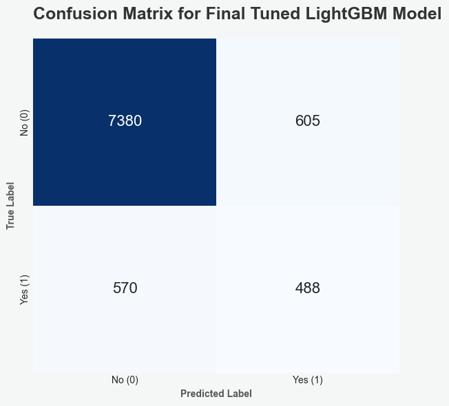

```
Final Model Performance:
```

|  | Precision | Recall | F1-Score | ROC AUC | Training Time (s) |
| --- | --- | --- | --- | --- | --- |
| Final Tuned LightGBM Model | 0.45 | 0.46 | 0.45 | 0.79 | 6.37 |

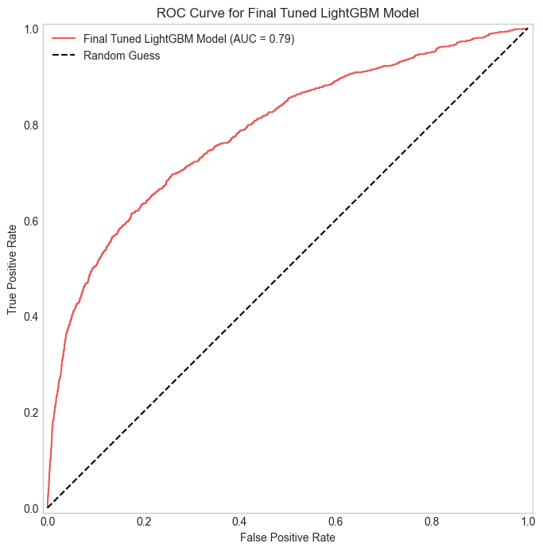

```python
# Retrieving the best set of hyperparameters
best_lgbm_params = study_lgbm.best_params

final_lgbm_model = LGBMClassifier(**best_lgbm_params, random_state=seed, n_jobs=-1, verbose=-1)

# Creating the final pipeline with the best LightGBM model
final_pipeline = ImbPipeline(steps=[
    ('preprocessor', preprocessor_engineered),
    ('smote', SMOTE(random_state=seed)),
    ('classifier', final_lgbm_model)
])

# Training the final model
print("\n--- Training Final LightGBM Model with Optimized Hyperparameters ---\n")
start_time = time.time()
final_pipeline.fit(X_train, y_train)
end_time = time.time()
training_time = end_time - start_time
print(f"Final LightGBM model trained in {training_time:.2f} seconds.")
y_pred_final = final_pipeline.predict(X_test)
y_proba_final = final_pipeline.predict_proba(X_test)[:, 1]

# Evaluating the final model
print("\n--- Final Model Evaluation ---\n")
print("Classification Report:\n")
print(classification_report(y_test, y_pred_final, target_names=['no', 'yes']))
plot_confusion_matrix(y_test, y_pred_final, "Final Tuned LightGBM Model")

final_metrics = {
    'Precision': precision_score(y_test, y_pred_final),
    'Recall': recall_score(y_test, y_pred_final),
    'F1-Score': f1_score(y_test, y_pred_final),
    'ROC AUC': roc_auc_score(y_test, y_proba_final),
    'Training Time (s)': training_time
}
final_resutls_df = pd.DataFrame([final_metrics], index=['Final Tuned LightGBM Model'])
print("\nFinal Model Performance:\n")
display(final_resutls_df.style.format({'Precision': '{:.2f}', 'Recall': '{:.2f}', 'F1-Score': '{:.2f}',
                                       'ROC AUC': '{:.2f}', 'Training Time (s)': '{:.2f}'}))
# Plotting ROC Curve for the final model
fig, ax = plt.subplots(figsize=(8, 8))
RocCurveDisplay.from_predictions(y_test, y_proba_final, name="Final Tuned LightGBM Model", color='#E85B5B', ax=ax)
ax.plot([0, 1], [0, 1], 'k--', label='Random Guess')
ax.set_title('ROC Curve for Final Tuned LightGBM Model')
ax.set_xlabel('False Positive Rate')
ax.set_ylabel('True Positive Rate')
ax.legend()
plt.grid()
plt.show()
```

- Our fine-tuned LightGBM is more **precise** (0.45 vs. 0.42), making fewer false positive errors.
- The Gradient Boosting model, on the other hand, had a slightly higher **Recall**, identifying more potential subscribers but at the cost of more wasted calls.

Given that the fine-tuned LightGBM models achieves a top-tier F1-score, has better precision, a superior ROC AUC for ranking leads, and is significantly more **computationally efficient**, we select it as our final model. It gives us the best combination of predictive power and practical usability for this business problem.

### Feature Importance

Now that we have a final model, the last step is to check its behavior. In this section, we will visualize feature importances from our fined-tuned LGBM model. The goal is to understand which data points are most influentional in its decision-making.

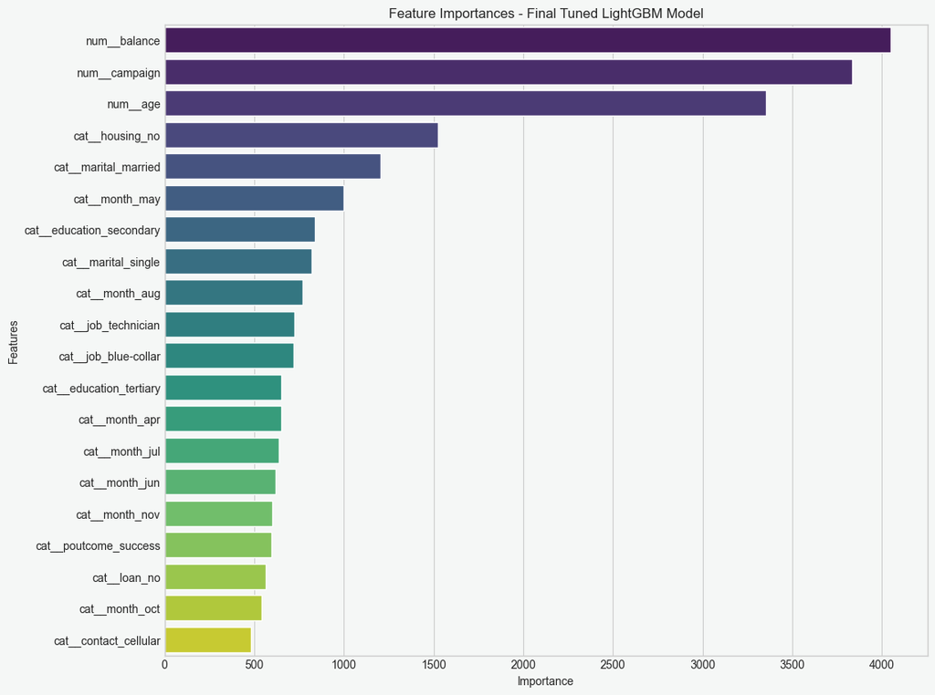

```python
# Computing Feature Importance
importances = final_pipeline.named_steps['classifier'].feature_importances_
feature_names = final_pipeline.named_steps['preprocessor'].get_feature_names_out()
feature_importances = pd.Series(importances, index=feature_names).sort_values(ascending=False).head(20)

# Plotting Feature Importances
plt.style.use('seaborn-v0_8-whitegrid')
fig,ax = plt.subplots(figsize=(12,10))
fig.set_facecolor('#f5f7f6')
ax.set_facecolor('#f5f7f6')

sns.barplot(x=feature_importances, y=feature_importances.index, ax=ax, palette='viridis')
ax.set_title('Feature Importances - Final Tuned LightGBM Model')
ax.set_xlabel('Importance')
ax.set_ylabel('Features')
plt.show()
```

- **Client Financial Profile**
  - The client's financial profile appears to be the most dominant factor in the model's predictions. `balance` is the top feature. We can also see that the model is also considering whether the client has an existing `housing` or `personal loan`. This strongly supports our hypothesis that clients with fewer existing financial liabilities are the primary target audience.
- **Campaign Strategy & Timing**
  - The `campaign` itself, specifically the number of contacts, is the second most important predictor, reinforcing that an optimized contact strategy is crucial. The **timing** of the campaign is also highly influential, with `month_may` (our least successful month) being a top predictor, alongside several other months. The outcome of a previous campaign (`poutcome_success`) also remains a key indicator.
- **Client Demographics**
  - `Age` is the third most powerful feature overall. Other demographic details like `marital` status, `education` level, and `job` type also contribute significantly to the model's predictions, allowing it to build a profile of likely subscribers.

### Saving Model

The final step is to save our trained model so it can be used in other applications. We'll use the joblib library to serialize our entire `final_pipeline` object to a file. Saving the complete pipeline is crucial, as it ensures the exact same preprocessing steps are applied to new data during prediction, guaranteeing consistent results. This file can then be loaded to make live predictions without needing to retrain the model.

```python
# Displaying final pipeline
final_pipeline
```

```
Pipeline(steps=[('preprocessor',
                 ColumnTransformer(transformers=[('cat',
                                                  OneHotEncoder(handle_unknown='ignore'),
                                                  Index(['job', 'marital', 'education', 'default', 'housing', 'loan', 'contact',
       'day_of_month', 'month', 'poutcome', 'was_previously_contacted',
       'had_previous_contact'],
      dtype='object')),
                                                 ('num', PowerTransformer(),
                                                  Index(['age', 'balance', 'campaign'], dtype='object'))])),
                ('smote', SMOTE(random_state=42)),
                ('classifier',
                 LGBMClassifier(colsample_bytree=0.8979866059177901,
                                learning_rate=0.01032565119154107, max_depth=10,
                                min_child_samples=45, n_estimators=200,
                                n_jobs=-1, num_leaves=1440, random_state=42,
                                reg_alpha=1.2879201869482782e-08,
                                reg_lambda=2.74426603318653e-06,
                                subsample=0.9643946012301383, verbose=-1))])
```

```python
# Saving model
model_dir = '../models'
file_name = 'final_lgbm_pipeline.joblib'
file_path = os.path.join(model_dir, file_name)

os.makedirs(model_dir, exist_ok=True)
joblib.dump(final_pipeline, file_path)

print(f"\nModel saved to {file_path}")
```

```
Model saved to ../models/final_lgbm_pipeline.joblib
```

## Conclusion

We have successfully developed a machine learning model to improve the efficiency of a bank's telemarketing campaigns. We followed a Data Science workflow, beginning with an Exploratory Data Analysis, then moving on to Data Pipeline & Preprocessing, and finally Model Selection and Fine-Tuning.  
Our final model, a fine-tuned LightGBM Classifier, achieved a F1-Score of 0.45 and a ROC AUC of 0.79 on the hold-out test set. This represents an improvement over our baseline and provides the bank with a tool to identify and prioritize high-potential clients.  
Our analysis confirmed the critical importance of campaign timing, client demographic (age, job), and financial profile (balance, existing loans). With these patterns, the final model can help the bank focus its resources more effectively, reducing costs associated with contacting uninterested clients, and ultimately increase its term deposit subscription rate. The saved pipeline is now ready for deployment in a production environment or an interactive application.